# lily

# Introduction

## 1.1 Defining the Question

identify which individuals who are most likely to click an ad

## 1.2 context

A Kenyan entrepreneur has created an online cryptography course and would want to advertise it on her blog. She currently targets audiences originating from various countries. In the past, she ran ads to advertise a related course on the same blog and collected data in the process. She would now like to employ my services as a Data Science Consultant to help her identify which individuals are most likely to click on her ads

## 1.3 Metrics for success

Getting to know which are the factors/features/variables that have the highest impact on the decision of a user clicking an ad

## 1.4 Experimental design

*Installing packages and loading libraries needed* Data understanding *Data preparation* EDA *Modelling* Conclusions

##1.5 Appropriateness of the Data The link of the dataset is http://bit.ly/IPAdvertisingData

#2Data understanding

##2.1Loading libraries and package

```r
# Install package data.table
install.packages("data.table")
library(data.table) # load package
```

```r
install.packages("tidyverse") # install packages to work with data frame - extends into visualization
library(tidyverse)
```

```r
install.packages("ggcorrplot")
library(ggcorrplot)
```

##2.2Loading dataset

```r
advert <- fread('http://bit.ly/IPAdvertisingData')
```

##2.3 previewing the dataset

```r
# Viewing the top observations
head(advert)
```

```
##    Daily Time Spent on Site Age Area Income Daily Internet Usage
## 1:                    68.95  35    61833.90               256.09
## 2:                    80.23  31    68441.85               193.77
## 3:                    69.47  26    59785.94               236.50
## 4:                    74.15  29    54806.18               245.89
## 5:                    68.37  35    73889.99               225.58
## 6:                    59.99  23    59761.56               226.74
##                            Ad Topic Line           City Male    Country
## 1:    Cloned 5thgeneration orchestration    Wrightburgh    0    Tunisia
## 2:    Monitored national standardization      West Jodi    1      Nauru
## 3:      Organic bottom-line service-desk       Davidton    0 San Marino
## 4: Triple-buffered reciprocal time-frame West Terrifurt    1      Italy
## 5:         Robust logistical utilization   South Manuel    0    Iceland
## 6:       Sharable client-driven software      Jamieberg    1     Norway
##              Timestamp Clicked on Ad
## 1: 2016-03-27 00:53:11             0
## 2: 2016-04-04 01:39:02             0
## 3: 2016-03-13 20:35:42             0
## 4: 2016-01-10 02:31:19             0
## 5: 2016-06-03 03:36:18             0
## 6: 2016-05-19 14:30:17             0
```

```r
# Viewing the bottom observations
tail(advert)
```

```
##    Daily Time Spent on Site Age Area Income Daily Internet Usage
## 1:                    43.70  28    63126.96               173.01
## 2:                    72.97  30    71384.57               208.58
## 3:                    51.30  45    67782.17               134.42
## 4:                    51.63  51    42415.72               120.37
## 5:                    55.55  19    41920.79               187.95
## 6:                    45.01  26    29875.80               178.35
##                           Ad Topic Line          City Male
## 1:        Front-line bifurcated ability  Nicholasland    0
## 2:        Fundamental modular algorithm     Duffystad    1
## 3:      Grass-roots cohesive monitoring   New Darlene    1
## 4:         Expanded intangible solution South Jessica    1
## 5: Proactive bandwidth-monitored policy   West Steven    0
## 6:      Virtual 5thgeneration emulation   Ronniemouth    0
##                   Country           Timestamp Clicked on Ad
## 1:                Mayotte 2016-04-04 03:57:48             1
## 2:                Lebanon 2016-02-11 21:49:00             1
## 3: Bosnia and Herzegovina 2016-04-22 02:07:01             1
## 4:               Mongolia 2016-02-01 17:24:57             1
## 5:              Guatemala 2016-03-24 02:35:54             0
## 6:                 Brazil 2016-06-03 21:43:21             1
```

```r
# Checking the number of rows and columns
dim(advert)
```

```
## [1] 1000   10
```

there are 1000 rows and 10 columns

```r
# checking the summary statistics of the dataset

summary(advert)
```

```
##  Daily Time Spent on Site      Age         Area Income    Daily Internet Usage
##  Min.   :32.60            Min.   :19.00   Min.   :13996   Min.   :104.8
##  1st Qu.:51.36            1st Qu.:29.00   1st Qu.:47032   1st Qu.:138.8
##  Median :68.22            Median :35.00   Median :57012   Median :183.1
##  Mean   :65.00            Mean   :36.01   Mean   :55000   Mean   :180.0
##  3rd Qu.:78.55            3rd Qu.:42.00   3rd Qu.:65471   3rd Qu.:218.8
##  Max.   :91.43            Max.   :61.00   Max.   :79485   Max.   :270.0
##  Ad Topic Line          City                Male         Country
##  Length:1000        Length:1000        Min.   :0.000   Length:1000
##  Class :character   Class :character   1st Qu.:0.000   Class :character
##  Mode  :character   Mode  :character   Median :0.000   Mode  :character
##                                        Mean   :0.481
##                                        3rd Qu.:1.000
##                                        Max.   :1.000
##   Timestamp         Clicked on Ad
##  Length:1000        Min.   :0.0
##  Class :character   1st Qu.:0.0
##  Mode  :character   Median :0.5
##                     Mean   :0.5
##                     3rd Qu.:1.0
##                     Max.   :1.0
```

Minimum age is 19,median ageis 35,mean age is 36.01,max age is 61,1st and 3rd quartile is 29 and 42 respectively

```r
# Summary information of the dataset
str(advert)
```

```
## Classes 'data.table' and 'data.frame':   1000 obs. of  10 variables:
##  $ Daily Time Spent on Site: num  69 80.2 69.5 74.2 68.4 ...
##  $ Age                     : int  35 31 26 29 35 23 33 48 30 20 ...
##  $ Area Income             : num  61834 68442 59786 54806 73890 ...
##  $ Daily Internet Usage    : num  256 194 236 246 226 ...
##  $ Ad Topic Line           : chr  "Cloned 5thgeneration orchestration" "Monitored national standardization" "Organic bottom-line service-desk" "Triple-buffered reciprocal time-frame" ...
##  $ City                    : chr  "Wrightburgh" "West Jodi" "Davidton" "West Terrifurt" ...
##  $ Male                    : int  0 1 0 1 0 1 0 1 1 1 ...
##  $ Country                 : chr  "Tunisia" "Nauru" "San Marino" "Italy" ...
##  $ Timestamp               : chr  "2016-03-27 00:53:11" "2016-04-04 01:39:02" "2016-03-13 20:35:42" "2016-01-10 02:31:19" ...
##  $ Clicked on Ad           : int  0 0 0 0 0 0 0 1 0 0 ...
##  - attr(*, ".internal.selfref")=<externalptr>
```

glimpse and str shows the datatypes of each column and a few observations.

#3Data preparation

## 3.1missing data

```r
# Checking for missing values by columns

colSums(is.na(advert))
```

```
## Daily Time Spent on Site                      Age              Area Income
##                        0                        0                        0
##     Daily Internet Usage            Ad Topic Line                     City
##                        0                        0                        0
##                     Male                  Country                Timestamp
##                        0                        0                        0
##            Clicked on Ad
##                        0
```

```r
# Checking for missing for the whole dataset
sum(is.na(advert))
```

```
## [1] 0
```

Both checks columnwise and as whole indicates there are no missing values

## 3.2duplicates

```r
# Checking for duplicates,which function checks and displays rows with duplicates though it only reports on the first instance of a duplicate report
which(duplicated(advert))
```

```
## integer(0)
```

```r
# Checking for duplicatesrows
duplicated_rows <- advert[duplicated(advert),]
duplicated_rows
```

```
## Empty data.table (0 rows and 10 cols): Daily Time Spent on Site,Age,Area Income,Daily Internet Usage,Ad Topic Line,City...
```

From the two checks ,it is observed that there are no duplicates

## 3.3Rectifing name system of the columns

```r
# Checking the column names
names(advert)
```

```
##  [1] "Daily Time Spent on Site" "Age"
##  [3] "Area Income"              "Daily Internet Usage"
##  [5] "Ad Topic Line"            "City"
##  [7] "Male"                     "Country"
##  [9] "Timestamp"                "Clicked on Ad"
```

```r
# Replacing spaces in the columns names with an underscore
names(advert) <- gsub(" ", "_", names(advert))
# Confirming the columns names have changed
names(advert)
```

```
##  [1] "Daily_Time_Spent_on_Site" "Age"
##  [3] "Area_Income"              "Daily_Internet_Usage"
##  [5] "Ad_Topic_Line"            "City"
##  [7] "Male"                     "Country"
##  [9] "Timestamp"                "Clicked_on_Ad"
```

## 3.4Outliers

```r
glimpse(advert)
```

```
## Rows: 1,000
## Columns: 10
## $ Daily_Time_Spent_on_Site <dbl> 68.95, 80.23, 69.47, 74.15, 68.37, 59.99, ...
## $ Age                      <int> 35, 31, 26, 29, 35, 23, 33, 48, 30, 20, 49...
## $ Area_Income              <dbl> 61833.90, 68441.85, 59785.94, 54806.18, 73...
## $ Daily_Internet_Usage     <dbl> 256.09, 193.77, 236.50, 245.89, 225.58, 22...
## $ Ad_Topic_Line            <chr> "Cloned 5thgeneration orchestration", "Mon...
## $ City                     <chr> "Wrightburgh", "West Jodi", "Davidton", "W...
## $ Male                     <int> 0, 1, 0, 1, 0, 1, 0, 1, 1, 1, 0, 1, 1, 0, ...
## $ Country                  <chr> "Tunisia", "Nauru", "San Marino", "Italy",...
## $ Timestamp                <chr> "2016-03-27 00:53:11", "2016-04-04 01:39:0...
## $ Clicked_on_Ad            <int> 0, 0, 0, 0, 0, 0, 0, 1, 0, 0, 1, 0, 1, 0, ...
```

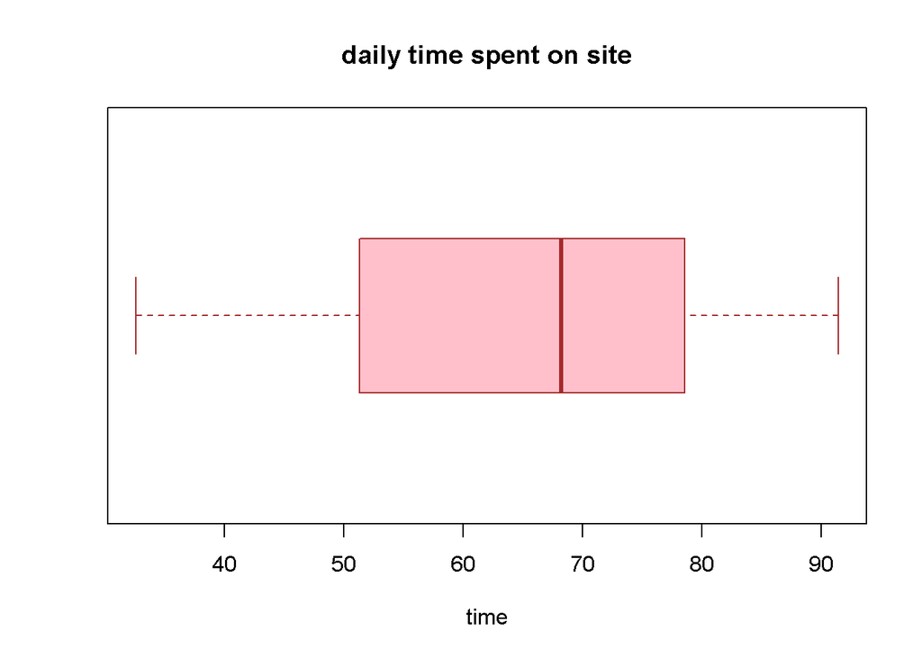

```r
boxplot(advert$Daily_Time_Spent_on_Site,col = "pink",main = "daily time spent on site",border = "brown",xlab="time",horizontal = T)
```

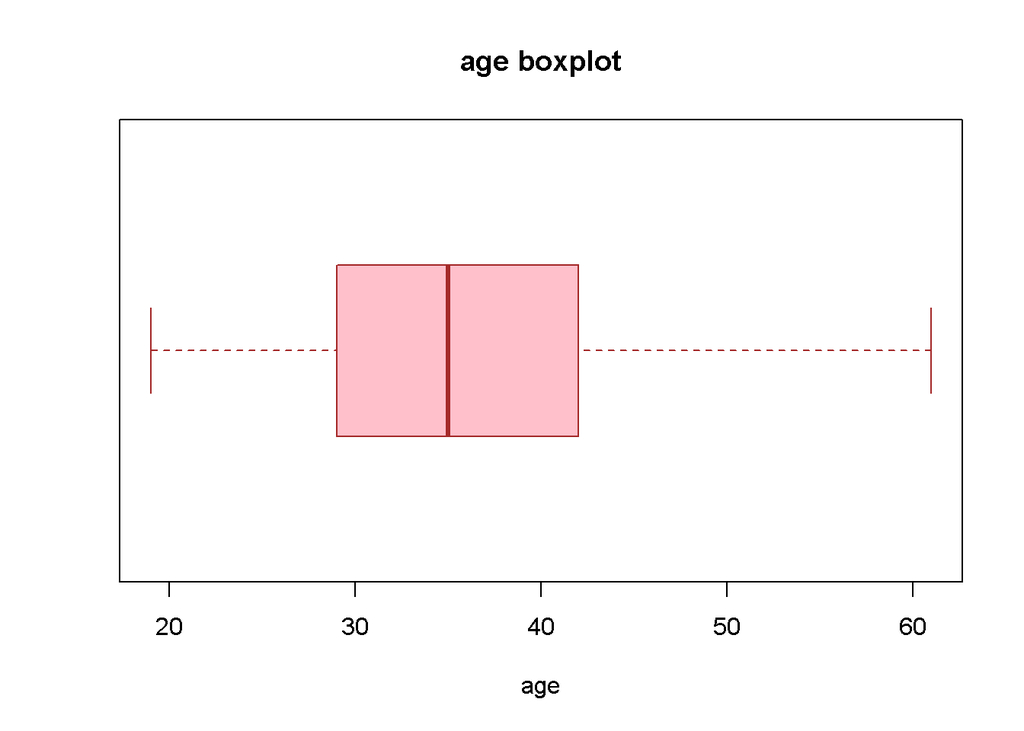

```r
boxplot(advert$Age,col = "pink",main = "age boxplot",border = "brown",xlab="age",horizontal = T)
```

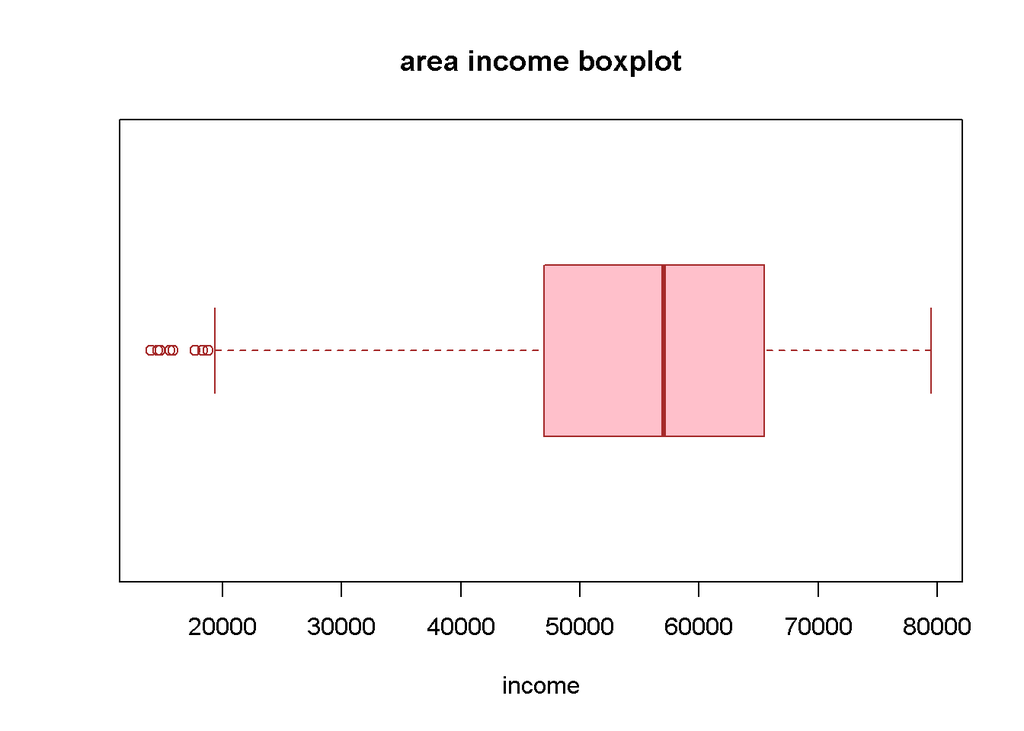

```r
boxplot(advert$Area_Income,col = "pink",main = "area income boxplot",border = "brown",xlab="income",horizontal = T)
```

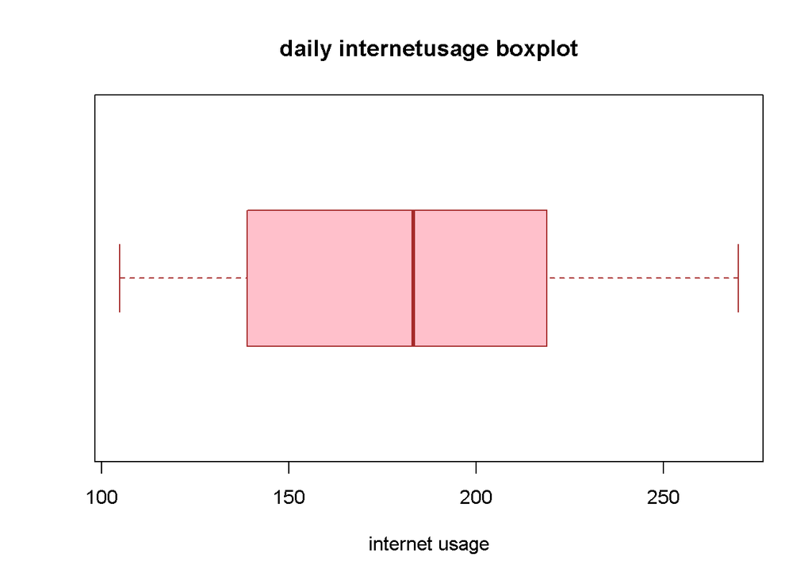

```r
boxplot(advert$Daily_Internet_Usage,col = "pink",main = "daily internetusage boxplot",border = "brown",xlab="internet usage",horizontal = T)
```

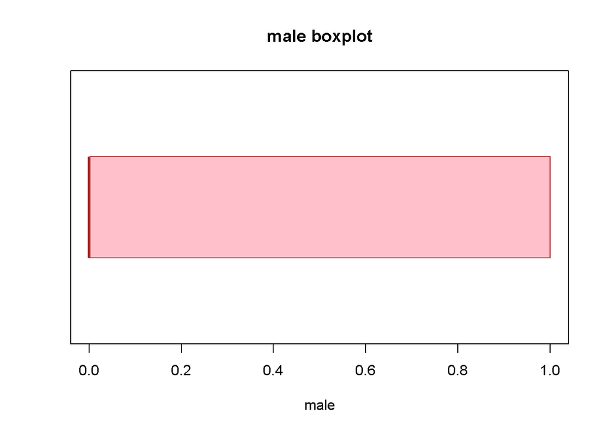

```r
boxplot(advert$Male,col = "pink",main = "male boxplot",border = "brown",xlab="male",horizontal = T)
```

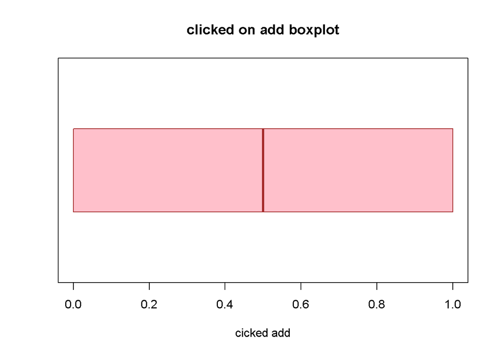

```r
boxplot(advert$Clicked_on_Ad,col = "pink",main = "clicked on add boxplot",border = "brown",xlab="cicked add",horizontal = T )
```

It is observed that its only area income that has outliers ,however i will not delete them at this point in time since upon further investigation could help the Kenyan entrepreneur to customize cerain aspects of the crypography course eg fee payment mode (to those customers whose income is below 20000) so as to attract as many customers as possible.This could possibly be achieved either by may be having a possibility of paying the fees in installments

#4 EDA

##4.1 Univariate

```r
#  one can get specific details by using various specific functions sich as mean,min,max,median,sd,quartile etc except mode which one has to create a function for
# example below is for finding mean of age
advertmean <- mean(advert$Age)
advertmean
```

```
## [1] 36.009
```

```r
# example below is for max Daily_Time_Spent_on_Site
advertmax <- max(advert$Daily_Time_Spent_on_Site)
advertmax
```

```
## [1] 91.43
```

```r
advertvar <- var(advert$Area_Income)
advertvar
```

```
## [1] 179952406
```

The variance for area income is very high which means the datapoints are very far from the mean which is 55000

```r
advertsd <- sd(advert$Area_Income)


advertsd
```

```
## [1] 13414.63
```

```r
advertrange <- range(advert$Daily_Internet_Usage)

# Printing out the variable advertrange  to show the range
# ---
#
advertrange
```

```
## [1] 104.78 269.96
```

The range of daily internet usage is between 104.78 to 269.96

```r
library(moments)

skewness(advert$Daily_Time_Spent_on_Site)
```

```
## [1] -0.3712026
```

The skewness here is -0.3712026. This value implies that the distribution of the data is slightly skewed to the left or negatively skewed. It is skewed to the left because the computed value is negative, and is slightly, because the value is close to zero.

```r
kurtosis(advert$Daily_Time_Spent_on_Site)
```

```
## [1] 1.903942
```

Kurtosis is a measure of whether the distribution is too peaked

"When both skewness and kurtosis are zero the pattern of responses is considered a normal distribution. For kurtosis, the general guideline is that if the number is greater than +1, the distribution is too peaked. Likewise, a kurtosis of less than –1 indicates a distribution that is too flat.

```r
# getting a frequency table of clicks on ads
clicks <- advert$Clicked_on_Ad

# Applying the table() function will compute the frequency distribution of the clicks variable
# ---
#
clicks.frequency<- table(clicks)

# Printing clicks below
# ---
#

clicks.frequency
```

```
## clicks
##   0   1
## 500 500
```

```r
getmode <- function(v) {
   uniqv <- unique(v)
   uniqv[which.max(tabulate(match(v, uniqv)))]
}

# Calculating the mode using out getmode() function
# ---
#
advertmode <- getmode(advert$Daily_Time_Spent_on_Site)

# Then printing out Daily_Time_Spent_on_Site mode
advertmode
```

```
## [1] 62.26
```

##4.2 Bivariate

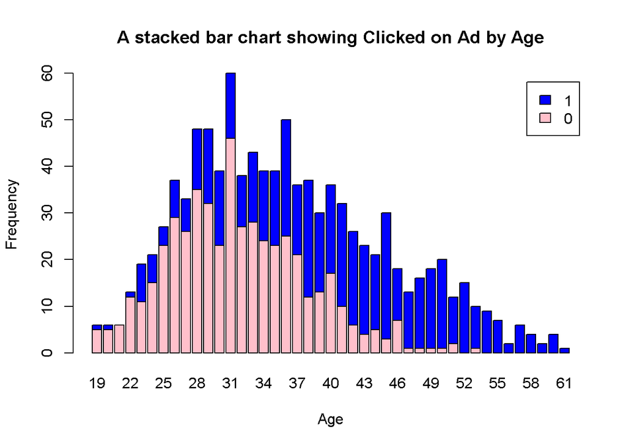

```r
click.count <- table(advert$Clicked_on_Ad, advert$Age)
barplot(click.count,
  main="A stacked bar chart showing Clicked on Ad by Age",
  xlab="Age",
  ylab = "Frequency",
  col=c("pink","blue"),
  legend = rownames(click.count))
```

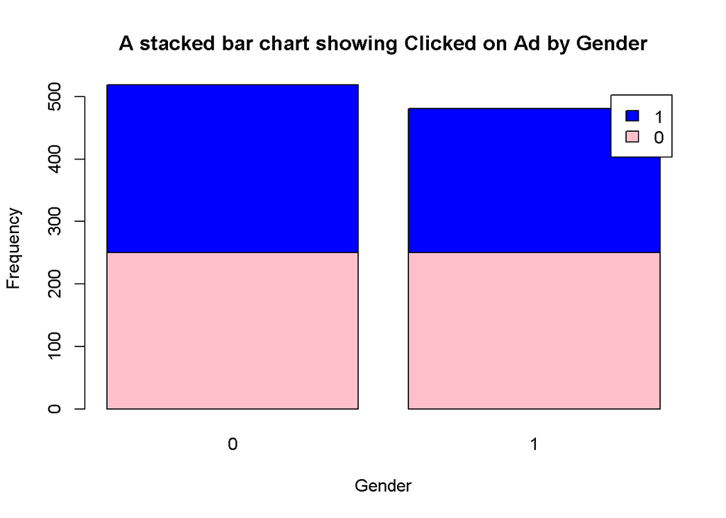

```r
click.count <- table(advert$Clicked_on_Ad, advert$Male)
barplot(click.count,
  main="A stacked bar chart showing Clicked on Ad by Gender",
  xlab="Gender",
  ylab = "Frequency",
  col=c("pink","blue"),
  legend = rownames(click.count))
```

Therr were slightly more females who clicked on the add as compared to males

```r
# Checking numeric columns
sapply(advert, is.numeric)
```

```
## Daily_Time_Spent_on_Site                      Age              Area_Income
##                     TRUE                     TRUE                     TRUE
##     Daily_Internet_Usage            Ad_Topic_Line                     City
##                     TRUE                    FALSE                    FALSE
##                     Male                  Country                Timestamp
##                     TRUE                    FALSE                    FALSE
##            Clicked_on_Ad
##                     TRUE
```

```r
# subsetting the numeric columns
advertnumeric <- advert[, sapply(advert, is.numeric)]
advertnumeric
```

```
## Daily_Time_Spent_on_Site                      Age              Area_Income
##                     TRUE                     TRUE                     TRUE
##     Daily_Internet_Usage            Ad_Topic_Line                     City
##                     TRUE                    FALSE                    FALSE
##                     Male                  Country                Timestamp
##                     TRUE                    FALSE                    FALSE
##            Clicked_on_Ad
##                     TRUE
```

```r
adv<-advert%>% select_if(is.numeric)
adv
```

```
##       Daily_Time_Spent_on_Site Age Area_Income Daily_Internet_Usage Male
##    1:                    68.95  35    61833.90               256.09    0
##    2:                    80.23  31    68441.85               193.77    1
##    3:                    69.47  26    59785.94               236.50    0
##    4:                    74.15  29    54806.18               245.89    1
##    5:                    68.37  35    73889.99               225.58    0
##   ---
##  996:                    72.97  30    71384.57               208.58    1
##  997:                    51.30  45    67782.17               134.42    1
##  998:                    51.63  51    42415.72               120.37    1
##  999:                    55.55  19    41920.79               187.95    0
## 1000:                    45.01  26    29875.80               178.35    0
##       Clicked_on_Ad
##    1:             0
##    2:             0
##    3:             0
##    4:             0
##    5:             0
##   ---
##  996:             1
##  997:             1
##  998:             1
##  999:             0
## 1000:             1
```

```r
# Calculate the correlations
corr <- cor(adv)
corr
```

```
##                          Daily_Time_Spent_on_Site         Age  Area_Income
## Daily_Time_Spent_on_Site               1.00000000 -0.33151334  0.310954413
## Age                                   -0.33151334  1.00000000 -0.182604955
## Area_Income                            0.31095441 -0.18260496  1.000000000
## Daily_Internet_Usage                   0.51865848 -0.36720856  0.337495533
## Male                                  -0.01895085 -0.02104406  0.001322359
## Clicked_on_Ad                         -0.74811656  0.49253127 -0.476254628
##                          Daily_Internet_Usage         Male Clicked_on_Ad
## Daily_Time_Spent_on_Site           0.51865848 -0.018950855   -0.74811656
## Age                               -0.36720856 -0.021044064    0.49253127
## Area_Income                        0.33749553  0.001322359   -0.47625463
## Daily_Internet_Usage               1.00000000  0.028012326   -0.78653918
## Male                               0.02801233  1.000000000   -0.03802747
## Clicked_on_Ad                     -0.78653918 -0.038027466    1.00000000
```

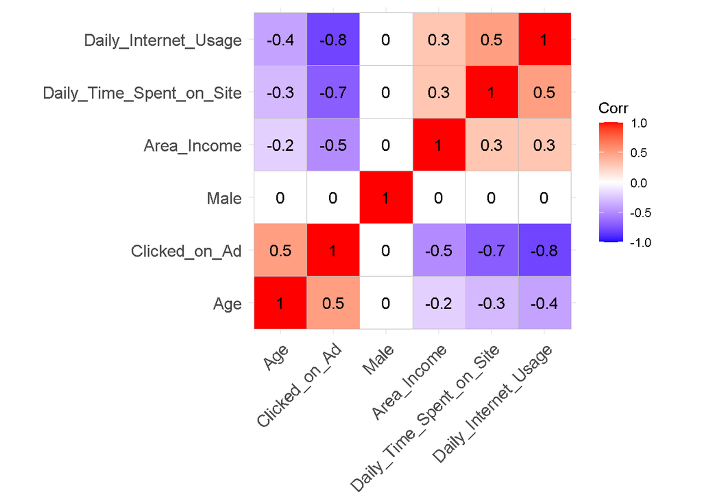

```r
ggcorrplot(round(corr, 1),
           type = "full", lab = T,hc.order = TRUE)
```

```r
install.packages("corrplot")
library(corrplot)
adv.cor = cor(adv)
adv.cor
```

```
##                          Daily_Time_Spent_on_Site         Age  Area_Income
## Daily_Time_Spent_on_Site               1.00000000 -0.33151334  0.310954413
## Age                                   -0.33151334  1.00000000 -0.182604955
## Area_Income                            0.31095441 -0.18260496  1.000000000
## Daily_Internet_Usage                   0.51865848 -0.36720856  0.337495533
## Male                                  -0.01895085 -0.02104406  0.001322359
## Clicked_on_Ad                         -0.74811656  0.49253127 -0.476254628
##                          Daily_Internet_Usage         Male Clicked_on_Ad
## Daily_Time_Spent_on_Site           0.51865848 -0.018950855   -0.74811656
## Age                               -0.36720856 -0.021044064    0.49253127
## Area_Income                        0.33749553  0.001322359   -0.47625463
## Daily_Internet_Usage               1.00000000  0.028012326   -0.78653918
## Male                               0.02801233  1.000000000   -0.03802747
## Clicked_on_Ad                     -0.78653918 -0.038027466    1.00000000
```

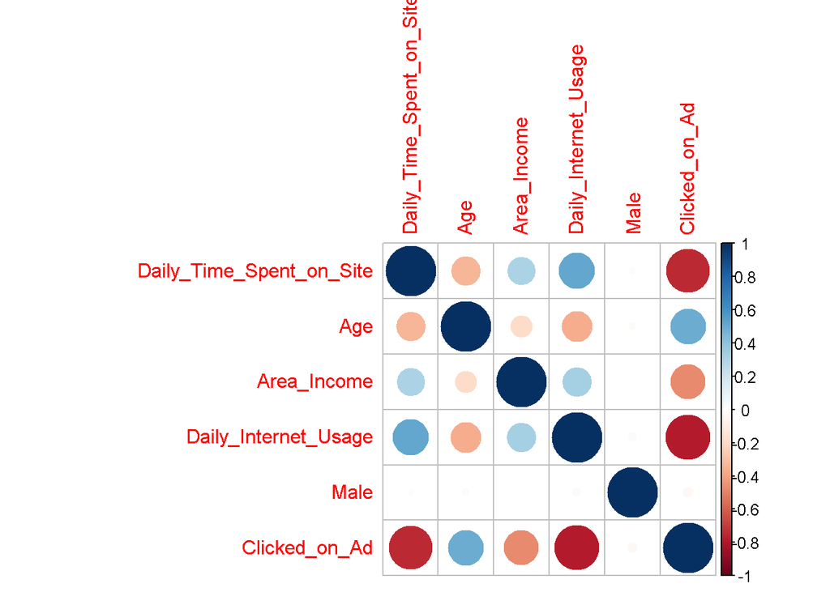

```r
corrplot(adv.cor)
```

Positive correlations are displayed in a blue scale while negative correlations are displayed in a red scale. there are regions that dont have any scale eg male and age,an indicator that there is no correlation between the two

#5 modeling

```r
# Converting the target as a factor

advert$Clicked_on_Ad = factor(advert$Clicked_on_Ad , levels = c(0,1))
```

```r
#Installing libraries
install.packages('rpart')
install.packages('caret')
```

```r
install.packages('rpart.plot')
install.packages('rattle')
install.packages("dprep")
#Loading libraries
library(rpart,quietly = TRUE)
library(caret,quietly = TRUE)
library(rpart.plot,quietly = TRUE)
library(rattle)
m <- rpart(Clicked_on_Ad ~ . ,
    data = advert,
    method = "class")
```

[figure not shown]

```r
rpart.plot(m)
```

```r
p <- predict(m, advert, type = "class")
table(p, advert$Clicked_on_Ad )
```

```
##
## p     0   1
##   0 500   0
##   1   0 500
```

```r
mean(advert$Clicked_on_Ad  == p)
```

```
## [1] 1
```